# 7th February

## Binning

Because audio event files can be different lengths, with a variety of ranges of frequencies, it can be very difficult to feed this raw signal component data into a neural network, as we would need to build in an ability to tackle dynamic ranges of data. Instead, we will bin the frequencies into set frequency bins.

```python
import pandas as pd
import numpy as np
import matplotlib.pyplot as plt
import os
from tqdm import tqdm
%matplotlib notebook
```

let's read in our data, now fourier-transformed and filtered. As an artifact of saving it as a dataframe earlier, we need to drop a residual auto-index column.

```python
manual_dataframe = pd.read_csv("E:/data/DATA/ASCII/AllData/headless_only/TimeseriesAndAmplitude/FFT_dB/20110829.002440.YW.NAB1.HHE.csv")
manual_dataframe.drop(["Unnamed: 0"], axis=1, inplace=True)
```

As discussed before, we cannot find any signals above half our sampling rate, Given our 0.01 second sample interval, that gives us a Niquist limit of $$\frac{1\ sample\ period}{0.01 seconds} = 100Hz\ sampling\ frequency = 50Hz\ ceiling$$

This leaves us with data in the region of 0 $\leq$ 50 Hz. We will use evenly spaced bins, of no more than 1Hz in width.

```python
manual_dataframe.groupby("bins")["Decibels"].mean().values
```

```
array([ -86.97294196,  -39.70095923,  -21.23051701,  -17.84478069,
        -13.6240034 ,  -12.304216  ,  -11.84190142,  -11.550472  ,
        -12.33308965,  -10.98734578,  -12.48573263,  -10.27576094,
         -8.06420249,  -12.57660514,   -9.56532323,   -9.65161731,
         -9.45788396,  -11.30567368,  -10.5418938 ,   -9.55547906,
        -13.87341529,  -13.46364547,  -13.60070104,  -13.54271936,
        -11.78047644,  -15.1818943 ,  -13.61043779,  -14.03463584,
        -12.49533026,  -18.30414888,  -17.32908754,  -19.93028897,
        -17.38176955,  -11.94454011,   -9.67665791,  -13.9909885 ,
        -19.09679493,  -14.83117957,  -13.12264223,  -11.10638351,
        -16.12959277,  -19.24885125,  -16.35647918,  -19.36431581,
        -14.94968659,  -12.78937417,  -17.05112502,  -17.99778793,
        -19.3669391 ,  -15.3156522 ,  -12.70576748,  -16.28514631,
        -22.45186933,  -20.20803604,  -13.63441853,  -24.93181927,
        -15.98861666,  -14.12795475,  -17.56494537,  -28.02731774,
        -27.92336054,  -20.54609126,  -25.77838656,  -15.25732721,
        -18.61057947,  -27.07721135,  -30.37591143,  -20.50342721,
        -21.982099  ,  -14.89371353,  -21.21332444,  -17.26552105,
        -16.96292161,  -16.75029655,  -18.59551152,  -22.17577621,
        -20.83592219,  -23.13706217,  -19.73040987,  -29.39683053,
        -26.06154774,  -23.11363084,  -29.93346082,  -24.10501349,
        -19.65467932,  -29.10066387,  -30.11849492,  -25.69343357,
        -25.10945635,  -24.19463618,  -27.29305625,  -26.4255342 ,
        -25.7080795 ,  -30.38637268,  -32.79560407,  -33.57186607,
        -39.34793411,  -39.16618559,  -40.63778609,  -37.67048508,
        -39.39459974,  -31.59500782,  -37.04775218,  -32.46875994,
        -36.80404194,  -35.87519655,  -39.68616692,  -42.89854098,
        -40.51774563,  -40.91845623,  -37.24332825,  -45.33175247,
        -46.42109425,  -43.42808013,  -50.68292908,  -42.68788388,
        -42.25549474,  -50.10288101,  -47.08062688,  -47.2952218 ,
        -52.75195147,  -45.80061486,  -48.17073416,  -53.96561158,
        -46.27407763,  -53.28852118,  -44.81742884,  -50.20622608,
        -60.46479737,  -61.00717399,  -57.91644421,  -63.61077398,
        -67.20551086,  -57.93689954,  -54.40380883,  -54.45024872,
        -62.18566071,  -65.16507204,  -64.69494082,  -62.03219326,
        -60.29898119,  -58.1496854 ,  -61.66477942,  -68.86024737,
        -70.51170848,  -66.62984953,  -63.84258758,  -68.04102929,
        -64.48996052,  -69.48272981,  -64.51045205,  -66.58295837,
        -65.68921485,  -65.12455304,  -66.75435491,  -69.47358983,
        -73.26462946,  -77.1934874 ,  -82.75627688,  -81.36844714,
        -80.40081515,  -81.75162519,  -83.85895326,  -82.56028364,
        -85.11452326,  -85.62823374,  -84.81029876,  -85.36973929,
        -87.75461181,  -93.35007818,  -94.29523058,  -93.60972593,
        -98.72948013, -101.00871634, -102.91121635, -102.56587605,
       -103.29360127, -106.347211  , -103.22280639, -102.94116212,
       -103.72254867, -106.54589942, -110.91670761, -113.79531553,
       -118.34358686, -120.95217573, -126.91339625, -130.2368107 ,
       -132.32474683, -137.18756121, -142.49162607, -144.97933242,
       -147.10612536, -150.72814738, -154.45098307, -155.49435209,
       -156.12589108, -154.32737971, -155.09531155, -155.84056649])
```

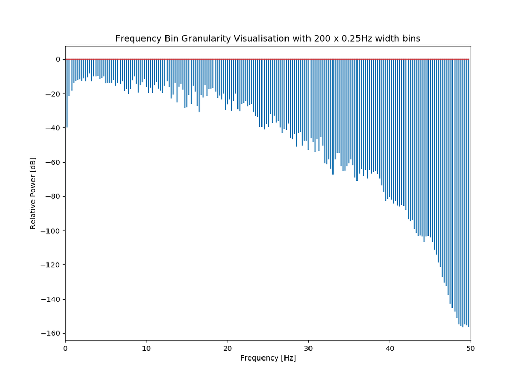

```python
no_of_bars = 200
break_points = np.linspace(0, 50, no_of_bars+1)
manual_dataframe['bins']=pd.cut(manual_dataframe["Sampling_Frequencies"],break_points, right=False)
manual_dataframe.groupby("bins")["Decibels"].mean()
index = np.arange(0, 50, 0.25)

with plt.style.context(('fast')):
    fig, ax = plt.subplots()
    ax.stem(index, manual_dataframe.groupby("bins")["Decibels"].mean().values, markerfmt=' ')
    ax.set_title("Frequency Bin Granularity Visualisation with 200 x 0.25Hz width bins")
    ax.set_xlabel("Frequency [Hz]")
    ax.set_ylabel("Relative Power [dB]")
    ax.set_xlim(0, 50)
    plt.show()
```

Now, we need to just add a few vital pieces of information to the binned data:

- The whole-event mean
- The whole-event median

And most vitally:

- The label

The label is what will tell Tensorflow if this is an event or not, and as we are running a binary classification experiment the value is either 1 (is an event) or 0 (is not an event). We will also add the name of the event - which we are adding manually for now but we will automate later - which will serve as the Primary Key.

```python
whole_event_mean = manual_dataframe['Decibels'].mean()
whole_event_median = manual_dataframe['Decibels'].median()

origin_filename = "20110829.002440.YW.NAB1.HHE"
stats_and_labels_dict = {'Mean': whole_event_mean,
                         'Median': whole_event_median,
                         'Label': 1}

attributes_dataseries = manual_dataframe.groupby("bins")["Decibels"].mean()

stats_and_labels_series = pd.Series(data=stats_and_labels_dict)
attributes_dataseries = pd.concat([stats_and_labels_series, attributes_dataseries])

attributes_dataframe = pd.DataFrame(data=attributes_dataseries, columns=[origin_filename])

attributes_dataframe
```

|  | 20110829.002440.YW.NAB1.HHE |
| --- | --- |
| Label | 1.000000 |
| Mean | -49.503608 |
| Median | -36.774117 |
| [0.0, 0.25) | -86.972942 |
| [0.25, 0.5) | -39.700959 |
| [0.5, 0.75) | -21.230517 |
| [0.75, 1.0) | -17.844781 |
| [1.0, 1.25) | -13.624003 |
| [1.25, 1.5) | -12.304216 |
| [1.5, 1.75) | -11.841901 |
| [1.75, 2.0) | -11.550472 |
| [2.0, 2.25) | -12.333090 |
| [2.25, 2.5) | -10.987346 |
| [2.5, 2.75) | -12.485733 |
| [2.75, 3.0) | -10.275761 |
| [3.0, 3.25) | -8.064202 |
| [3.25, 3.5) | -12.576605 |
| [3.5, 3.75) | -9.565323 |
| [3.75, 4.0) | -9.651617 |
| [4.0, 4.25) | -9.457884 |
| [4.25, 4.5) | -11.305674 |
| [4.5, 4.75) | -10.541894 |
| [4.75, 5.0) | -9.555479 |
| [5.0, 5.25) | -13.873415 |
| [5.25, 5.5) | -13.463645 |
| [5.5, 5.75) | -13.600701 |
| [5.75, 6.0) | -13.542719 |
| [6.0, 6.25) | -11.780476 |
| [6.25, 6.5) | -15.181894 |
| [6.5, 6.75) | -13.610438 |
| ... | ... |
| [42.5, 42.75) | -94.295231 |
| [42.75, 43.0) | -93.609726 |
| [43.0, 43.25) | -98.729480 |
| [43.25, 43.5) | -101.008716 |
| [43.5, 43.75) | -102.911216 |
| [43.75, 44.0) | -102.565876 |
| [44.0, 44.25) | -103.293601 |
| [44.25, 44.5) | -106.347211 |
| [44.5, 44.75) | -103.222806 |
| [44.75, 45.0) | -102.941162 |
| [45.0, 45.25) | -103.722549 |
| [45.25, 45.5) | -106.545899 |
| [45.5, 45.75) | -110.916708 |
| [45.75, 46.0) | -113.795316 |
| [46.0, 46.25) | -118.343587 |
| [46.25, 46.5) | -120.952176 |
| [46.5, 46.75) | -126.913396 |
| [46.75, 47.0) | -130.236811 |
| [47.0, 47.25) | -132.324747 |
| [47.25, 47.5) | -137.187561 |
| [47.5, 47.75) | -142.491626 |
| [47.75, 48.0) | -144.979332 |
| [48.0, 48.25) | -147.106125 |
| [48.25, 48.5) | -150.728147 |
| [48.5, 48.75) | -154.450983 |
| [48.75, 49.0) | -155.494352 |
| [49.0, 49.25) | -156.125891 |
| [49.25, 49.5) | -154.327380 |
| [49.5, 49.75) | -155.095312 |
| [49.75, 50.0) | -155.840566 |

203 rows × 1 columns

Now, we transpose the dataframe...

```python
attributes_dataframe = attributes_dataframe.transpose()
attributes_dataframe
```

|  | Label | Mean | Median | [0.0, 0.25) | [0.25, 0.5) | [0.5, 0.75) | [0.75, 1.0) | [1.0, 1.25) | [1.25, 1.5) | [1.5, 1.75) | ... | [47.5, 47.75) | [47.75, 48.0) | [48.0, 48.25) | [48.25, 48.5) | [48.5, 48.75) | [48.75, 49.0) | [49.0, 49.25) | [49.25, 49.5) | [49.5, 49.75) | [49.75, 50.0) |
| --- | --- | --- | --- | --- | --- | --- | --- | --- | --- | --- | --- | --- | --- | --- | --- | --- | --- | --- | --- | --- | --- |
| 20110829.002440.YW.NAB1.HHE | 1.0 | -49.503608 | -36.774117 | -86.972942 | -39.700959 | -21.230517 | -17.844781 | -13.624003 | -12.304216 | -11.841901 | ... | -142.491626 | -144.979332 | -147.106125 | -150.728147 | -154.450983 | -155.494352 | -156.125891 | -154.32738 | -155.095312 | -155.840566 |

1 rows × 203 columns

...and we have a row for our Tensorflow attribute database.

Now we need to automate this for the rest of the events, and append them to the attributes_dataframe.

## Automation

Let's summarise our steps above into a function, like we have before.

```python
file_list = os.listdir("../../../DATA/ASCII/AllData/headless_only/TimeseriesAndAmplitude/FFT_dB/")[1:]
#skipping the first item in the list which we have already processed

primary_key_name = map(lambda x: x[:-4], file_list)

filepath_list = map(lambda x: "../../../DATA/ASCII/AllData/headless_only/TimeseriesAndAmplitude/FFT_dB/" + x, file_list)

def fft_to_attribute(input_filepath, event_code, output_dataframe, no_of_bins, is_event_boolean):
    break_points = np.linspace(0, 50, no_of_bins+1)
    input_dataframe = pd.read_csv(input_filepath)
    input_dataframe.drop(["Unnamed: 0"], axis=1, inplace=True)
    input_dataframe['bins']=pd.cut(input_dataframe["Sampling_Frequencies"],break_points, right=False)

    whole_event_mean = input_dataframe['Decibels'].mean()
    whole_event_median = input_dataframe['Decibels'].median()
    origin_filename = event_code
    stats_and_labels_dict = {'Mean': whole_event_mean,
                         'Median': whole_event_median,
                         'Label': is_event_boolean}

    intermediary_dataseries = input_dataframe.groupby("bins")["Decibels"].mean()

    stats_and_labels_series = pd.Series(data=stats_and_labels_dict)
    intermediary_dataseries = pd.concat([stats_and_labels_series, intermediary_dataseries])

    intermediary_dataframe = pd.DataFrame(data=intermediary_dataseries, columns=[origin_filename])
    intermediary_dataframe = intermediary_dataframe.transpose()
    return pd.concat([output_dataframe, intermediary_dataframe])
```

```python
i = 0
for event in tqdm(filepath_list):
    file_path = filepath_list[i]
    event_key = primary_key_name[i]
    output_df = attributes_dataframe
    bin_no = 200
    event_bool = 1
    attributes_dataframe = fft_to_attribute(file_path, event_key, attributes_dataframe, bin_no, event_bool)
    i += 1
```

```python
plotter_df = attributes_dataframe.copy()
```

```python
plotter_df
```

|  | Label | Mean | Median | [0.0, 0.25) | [0.25, 0.5) | [0.5, 0.75) | [0.75, 1.0) | [1.0, 1.25) | [1.25, 1.5) | [1.5, 1.75) | ... | [47.5, 47.75) | [47.75, 48.0) | [48.0, 48.25) | [48.25, 48.5) | [48.5, 48.75) | [48.75, 49.0) | [49.0, 49.25) | [49.25, 49.5) | [49.5, 49.75) | [49.75, 50.0) |
| --- | --- | --- | --- | --- | --- | --- | --- | --- | --- | --- | --- | --- | --- | --- | --- | --- | --- | --- | --- | --- | --- |
| 20110829.002440.YW.NAB1.HHE | 1.0 | -49.503608 | -36.774117 | -86.972942 | -39.700959 | -21.230517 | -17.844781 | -13.624003 | -12.304216 | -11.841901 | ... | -142.491626 | -144.979332 | -147.106125 | -150.728147 | -154.450983 | -155.494352 | -156.125891 | -154.327380 | -155.095312 | -155.840566 |
| 20110829.002440.YW.NAB1.HHN | 1.0 | -52.970275 | -41.527855 | -90.157762 | -39.536188 | -23.780371 | -19.887141 | -18.773700 | -14.437797 | -11.379199 | ... | -139.962799 | -144.972489 | -149.093737 | -154.047340 | -157.389903 | -157.739307 | -160.250453 | -159.499526 | -160.626366 | -159.044227 |
| 20110829.002440.YW.NAB1.HHZ | 1.0 | -49.404476 | -35.705364 | -85.360751 | -42.308935 | -28.984454 | -25.323562 | -22.029361 | -17.178034 | -17.936891 | ... | -136.749538 | -142.005333 | -147.911374 | -150.243438 | -152.927957 | -155.484515 | -153.352313 | -155.520351 | -155.882318 | -154.457642 |
| 20110829.002440.YW.NAB2.HHE | 1.0 | -55.842953 | -42.811731 | -90.048085 | -37.702710 | -16.992135 | -15.982051 | -14.950209 | -12.954175 | -12.236898 | ... | -145.698153 | -146.225606 | -149.872257 | -153.348489 | -156.742817 | -155.391873 | -156.668775 | -157.172127 | -158.091982 | -157.850170 |
| 20110829.002440.YW.NAB2.HHN | 1.0 | -52.760978 | -39.839301 | -90.172687 | -35.951499 | -15.882029 | -10.882761 | -11.881504 | -10.974346 | -11.617730 | ... | -141.947521 | -141.462043 | -147.085346 | -153.623803 | -153.850766 | -154.224668 | -155.649332 | -152.178688 | -154.978403 | -150.293955 |
| 20110829.002440.YW.NAB2.HHZ | 1.0 | -53.964521 | -41.056191 | -87.519636 | -40.578987 | -25.918847 | -22.896412 | -19.010338 | -16.262827 | -15.901616 | ... | -143.283436 | -143.173910 | -149.405326 | -152.450883 | -153.294818 | -150.759121 | -153.039339 | -155.033794 | -155.916564 | -152.663575 |
| 20110829.002440.YW.NAB3.HHE | 1.0 | -51.540873 | -37.268183 | -88.204157 | -38.463515 | -17.364537 | -14.715513 | -12.662457 | -10.236065 | -10.259328 | ... | -139.961193 | -144.943610 | -149.793345 | -148.901692 | -155.776099 | -153.858385 | -157.674753 | -154.827184 | -156.665488 | -155.563266 |
| 20110829.002440.YW.NAB3.HHN | 1.0 | -52.278512 | -40.774709 | -90.555453 | -39.092960 | -19.182623 | -15.201570 | -15.057577 | -11.438610 | -11.343466 | ... | -142.403909 | -146.273892 | -152.476119 | -155.126666 | -156.433535 | -155.961537 | -152.965036 | -156.799395 | -157.695086 | -157.682605 |
| 20110829.002440.YW.NAB3.HHZ | 1.0 | -51.285219 | -38.195915 | -82.441493 | -39.425277 | -22.569698 | -17.912839 | -13.688495 | -13.438325 | -11.241495 | ... | -140.130491 | -143.840472 | -149.785955 | -151.172483 | -154.668444 | -155.695584 | -158.639437 | -156.559715 | -155.166477 | -155.675589 |
| 20110829.002440.YW.NAB4.HHE | 1.0 | -50.654045 | -36.682064 | -94.186642 | -48.015379 | -34.689453 | -32.725940 | -33.226503 | -29.435676 | -25.070562 | ... | -140.042334 | -142.713715 | -147.256188 | -155.919204 | -152.342803 | -153.925146 | -158.752572 | -153.597314 | -152.409728 | -150.697705 |
| 20110829.002440.YW.NAB4.HHN | 1.0 | -51.652909 | -36.978529 | -94.939854 | -49.860718 | -31.520148 | -32.782578 | -34.175768 | -32.708485 | -24.667089 | ... | -144.701766 | -147.875111 | -150.094576 | -148.920895 | -154.279361 | -156.546838 | -156.625964 | -157.405257 | -155.885119 | -160.634894 |
| 20110829.002440.YW.NAB4.HHZ | 1.0 | -45.538536 | -31.612022 | -84.909672 | -41.468161 | -29.547359 | -27.074693 | -29.973590 | -30.016891 | -29.747137 | ... | -134.914705 | -134.956742 | -137.952471 | -147.898656 | -152.238182 | -154.454257 | -152.025519 | -150.312141 | -155.393304 | -155.216105 |
| 20110829.002440.YW.NAB5.HHE | 1.0 | -60.294306 | -46.574855 | -110.064089 | -63.582253 | -43.701046 | -40.441535 | -35.989292 | -34.296761 | -30.113535 | ... | -157.018353 | -157.181912 | -156.424185 | -160.095678 | -158.499516 | -158.125517 | -153.957448 | -155.934731 | -156.673536 | -155.986593 |
| 20110829.002440.YW.NAB5.HHN | 1.0 | -59.418772 | -45.811793 | -111.643827 | -58.355957 | -43.592897 | -39.609540 | -33.898404 | -32.903199 | -27.484336 | ... | -155.676689 | -152.266207 | -158.304191 | -157.278369 | -159.046347 | -160.837821 | -158.990397 | -152.838588 | -155.694309 | -151.866151 |
| 20110829.002440.YW.NAB5.HHZ | 1.0 | -51.523849 | -35.711180 | -102.278935 | -51.795685 | -36.639962 | -34.583905 | -30.421783 | -24.713292 | -22.446362 | ... | -149.876556 | -155.875612 | -155.183063 | -153.258809 | -153.808203 | -156.097486 | -151.716564 | -153.611714 | -153.227812 | -149.249281 |
| 20110829.002440.YW.NAB6.HHE | 1.0 | -50.260507 | -35.415854 | -89.901571 | -40.632245 | -23.797671 | -19.264055 | -13.630374 | -13.950278 | -10.570510 | ... | -150.766298 | -155.079935 | -151.697667 | -153.879180 | -158.067191 | -155.481113 | -154.498866 | -153.554248 | -152.876105 | -157.361017 |
| 20110829.002440.YW.NAB6.HHN | 1.0 | -50.893790 | -35.492018 | -91.929674 | -38.928301 | -21.832325 | -14.566132 | -15.635337 | -17.565558 | -13.880497 | ... | -152.960525 | -154.231461 | -151.221046 | -156.391809 | -155.158713 | -158.158348 | -154.514614 | -156.096099 | -152.740884 | -154.730828 |
| 20110829.002440.YW.NAB6.HHZ | 1.0 | -47.015613 | -29.213867 | -91.858295 | -39.346272 | -27.714112 | -24.687423 | -23.911300 | -19.659315 | -14.659443 | ... | -153.519164 | -153.812756 | -152.094486 | -154.702323 | -152.536240 | -160.712935 | -157.755141 | -155.878569 | -154.421183 | -157.349720 |
| 20110829.030718.YW.NAB1.HHE | 1.0 | -52.915460 | -38.600833 | -88.549750 | -39.259057 | -23.984369 | -19.101874 | -16.331172 | -14.430741 | -14.605129 | ... | -146.425137 | -148.856552 | -152.782521 | -155.342744 | -156.101092 | -160.173323 | -159.816587 | -157.865354 | -157.531225 | -157.877265 |
| 20110829.030718.YW.NAB1.HHN | 1.0 | -51.604199 | -38.682209 | -87.418045 | -39.246077 | -21.751747 | -17.397584 | -15.881878 | -15.258042 | -14.845118 | ... | -135.855462 | -138.119082 | -143.487242 | -148.031236 | -152.125584 | -156.637590 | -157.136974 | -156.617173 | -156.139248 | -155.431559 |
| 20110829.030718.YW.NAB1.HHZ | 1.0 | -49.507979 | -34.566774 | -82.311005 | -40.600668 | -27.211801 | -25.641133 | -21.813150 | -20.057507 | -17.609649 | ... | -140.967064 | -143.067769 | -147.726714 | -151.246972 | -152.268420 | -152.587464 | -155.843811 | -157.251051 | -156.975234 | -156.612543 |
| 20110829.030718.YW.NAB2.HHE | 1.0 | -57.694780 | -45.971327 | -88.017579 | -38.499690 | -16.955419 | -14.264459 | -14.515491 | -14.260501 | -14.165127 | ... | -141.945546 | -146.810478 | -148.924743 | -153.240226 | -154.000803 | -155.563925 | -154.917250 | -156.561872 | -156.615298 | -157.040562 |
| 20110829.030718.YW.NAB2.HHN | 1.0 | -58.992178 | -47.707745 | -93.275817 | -40.669443 | -18.946492 | -17.881292 | -18.165048 | -16.073757 | -17.870911 | ... | -142.023036 | -146.700986 | -148.761878 | -153.050924 | -157.038313 | -156.054306 | -160.215266 | -158.028280 | -158.685580 | -157.596383 |
| 20110829.030718.YW.NAB2.HHZ | 1.0 | -55.918461 | -45.474664 | -83.636161 | -41.179659 | -27.402197 | -24.120518 | -19.233096 | -16.418589 | -18.420146 | ... | -139.483323 | -143.832675 | -146.762399 | -151.601966 | -154.610489 | -158.411808 | -158.301939 | -157.535331 | -156.980930 | -156.613991 |
| 20110829.030718.YW.NAB3.HHE | 1.0 | -55.548463 | -42.272181 | -86.745183 | -38.050223 | -18.199503 | -15.095415 | -12.439532 | -11.666787 | -13.044564 | ... | -142.761914 | -146.814403 | -150.395767 | -153.948852 | -157.505469 | -158.626217 | -157.069386 | -156.857750 | -160.685597 | -156.999573 |
| 20110829.030718.YW.NAB3.HHN | 1.0 | -56.731411 | -45.544152 | -88.353063 | -37.294724 | -20.232768 | -15.115275 | -12.974143 | -12.122232 | -11.895610 | ... | -146.795066 | -151.553951 | -153.752642 | -156.164129 | -157.627526 | -157.983550 | -159.250661 | -157.632335 | -158.970139 | -160.844684 |
| 20110829.030718.YW.NAB3.HHZ | 1.0 | -52.857452 | -39.525761 | -81.161389 | -35.675311 | -21.825918 | -13.493464 | -13.129959 | -12.033423 | -10.785869 | ... | -140.402808 | -143.049411 | -146.346935 | -151.333660 | -154.485811 | -154.832394 | -156.332975 | -158.635336 | -157.679534 | -156.987425 |
| 20110829.030718.YW.NAB4.HHE | 1.0 | -55.403656 | -41.640471 | -91.559377 | -48.710644 | -35.378025 | -32.277000 | -30.165400 | -28.793110 | -28.743323 | ... | -141.680683 | -146.168969 | -152.007703 | -154.419439 | -155.718487 | -158.799160 | -157.954390 | -157.909612 | -159.565938 | -158.790654 |
| 20110829.030718.YW.NAB4.HHN | 1.0 | -53.377557 | -39.948800 | -89.892871 | -46.480986 | -31.845587 | -29.095558 | -27.651088 | -25.796332 | -26.846419 | ... | -136.823057 | -141.862744 | -148.176579 | -152.564412 | -154.843604 | -156.009844 | -157.813016 | -154.998967 | -156.020289 | -157.931727 |
| 20110829.030718.YW.NAB4.HHZ | 1.0 | -46.633813 | -32.299333 | -79.130126 | -36.216671 | -25.698905 | -24.623738 | -25.582024 | -26.579205 | -27.959195 | ... | -129.524295 | -133.678746 | -137.875288 | -144.879015 | -148.107221 | -153.789821 | -155.968143 | -154.958355 | -155.646560 | -153.551872 |
| ... | ... | ... | ... | ... | ... | ... | ... | ... | ... | ... | ... | ... | ... | ... | ... | ... | ... | ... | ... | ... | ... |
| 20110907.220713.YW.NAB1.HHE | 1.0 | -80.682699 | -74.137456 | -116.161488 | -59.446737 | -36.378971 | -23.815012 | -18.043998 | -13.169801 | -10.924805 | ... | -158.314622 | -160.322283 | -160.729895 | -157.383745 | -157.494225 | -156.702896 | -161.866169 | -162.378206 | -159.064220 | -160.656907 |
| 20110907.220713.YW.NAB1.HHN | 1.0 | -78.087557 | -73.376696 | -111.841590 | -61.014755 | -35.009008 | -23.570332 | -14.551396 | -10.601593 | -9.900380 | ... | -159.615789 | -156.139589 | -157.964274 | -154.388459 | -160.543268 | -158.410280 | -163.027455 | -155.754406 | -157.075643 | -155.789950 |
| 20110907.220713.YW.NAB1.HHZ | 1.0 | -74.288656 | -64.207557 | -112.114563 | -57.410147 | -39.017659 | -28.667660 | -17.429941 | -12.177503 | -9.381880 | ... | -159.318974 | -156.307374 | -159.082704 | -154.117997 | -154.909115 | -159.285806 | -158.210090 | -155.671418 | -158.302944 | -157.538120 |
| 20110907.220713.YW.NAB2.HHE | 1.0 | -85.206182 | -78.692105 | -122.970550 | -60.956471 | -33.317789 | -27.657634 | -20.776207 | -16.784374 | -12.824027 | ... | -161.191317 | -163.835828 | -161.406823 | -161.464845 | -162.929143 | -160.398057 | -160.696595 | -159.452816 | -163.389669 | -163.712947 |
| 20110907.220713.YW.NAB2.HHN | 1.0 | -80.317067 | -74.361737 | -119.323624 | -59.539546 | -35.239356 | -24.311467 | -16.316946 | -12.833162 | -7.347468 | ... | -157.219525 | -155.049793 | -155.978815 | -156.596884 | -158.899353 | -156.414553 | -156.759230 | -156.173426 | -159.167466 | -159.302841 |
| 20110907.220713.YW.NAB2.HHZ | 1.0 | -78.872357 | -72.698778 | -117.771660 | -57.798934 | -42.448700 | -27.417021 | -19.428130 | -13.952178 | -10.219089 | ... | -158.703065 | -158.418292 | -158.721467 | -158.325820 | -158.020731 | -157.494271 | -163.870066 | -158.816423 | -159.655801 | -161.553706 |
| 20110907.220713.YW.NAB3.HHE | 1.0 | -82.653826 | -79.587831 | -116.100105 | -58.895070 | -35.268326 | -25.849844 | -20.754044 | -11.079693 | -7.948560 | ... | -160.039725 | -164.034737 | -159.940934 | -164.251912 | -158.682716 | -159.828583 | -158.627225 | -159.635456 | -156.814076 | -161.578746 |
| 20110907.220713.YW.NAB3.HHN | 1.0 | -81.342446 | -79.763369 | -114.198168 | -53.034791 | -35.139330 | -25.633322 | -17.485728 | -12.456556 | -9.089823 | ... | -162.252152 | -158.664473 | -159.100076 | -160.060495 | -163.083147 | -159.005025 | -160.115042 | -158.950974 | -160.630691 | -161.982659 |
| 20110907.220713.YW.NAB3.HHZ | 1.0 | -81.814683 | -77.963957 | -112.994905 | -58.693424 | -39.731522 | -28.378427 | -20.194959 | -13.986373 | -11.564960 | ... | -157.199466 | -156.780040 | -161.786339 | -157.267786 | -161.961720 | -162.644582 | -161.840092 | -165.013233 | -162.040758 | -162.236760 |
| 20110907.220713.YW.NAB4.HHE | 1.0 | -73.267521 | -63.170059 | -120.019399 | -64.300148 | -44.955505 | -39.482184 | -26.399981 | -18.936138 | -13.709215 | ... | -161.338768 | -156.371783 | -164.522120 | -162.082578 | -161.666924 | -157.613482 | -155.850422 | -158.264224 | -156.946501 | -157.546738 |
| 20110907.220713.YW.NAB4.HHN | 1.0 | -71.696515 | -62.114329 | -118.095151 | -63.336892 | -45.000032 | -36.560329 | -25.602689 | -23.654666 | -9.167275 | ... | -153.302999 | -155.364388 | -160.185439 | -157.483825 | -156.569678 | -159.810875 | -159.911067 | -156.688593 | -158.574771 | -158.236023 |
| 20110907.220713.YW.NAB4.HHZ | 1.0 | -68.422220 | -58.237401 | -114.078338 | -56.390774 | -38.664225 | -32.188355 | -24.096304 | -20.014375 | -18.270612 | ... | -155.320849 | -158.655085 | -157.171190 | -159.681242 | -155.905189 | -156.640800 | -156.624244 | -156.693197 | -161.180100 | -159.580318 |
| 20110907.220713.YW.NAB8.HHE | 1.0 | -68.318562 | -59.787704 | -104.717301 | -51.261719 | -34.674035 | -23.157818 | -16.746908 | -13.490482 | -10.436272 | ... | -153.721580 | -157.039993 | -155.750844 | -153.921198 | -153.783767 | -156.216362 | -153.769795 | -155.649452 | -156.643822 | -159.872825 |
| 20110907.220713.YW.NAB8.HHN | 1.0 | -73.868362 | -65.955974 | -108.324606 | -53.787815 | -37.870998 | -29.483597 | -19.415777 | -17.751838 | -15.885464 | ... | -161.931538 | -161.211611 | -165.812420 | -164.573600 | -161.507401 | -159.412759 | -161.793521 | -159.031299 | -160.953236 | -162.004335 |
| 20110907.220713.YW.NAB8.HHZ | 1.0 | -70.333732 | -62.422318 | -108.771742 | -46.974334 | -34.451259 | -25.120961 | -16.210029 | -13.594442 | -13.665399 | ... | -160.686659 | -159.410559 | -158.853382 | -157.706094 | -155.794459 | -157.672748 | -158.111745 | -162.355059 | -158.053631 | -157.903476 |
| 20110907.234429.YW.NAB1.HHE | 1.0 | -52.053720 | -37.656519 | -92.888573 | -51.108131 | -28.213051 | -23.410317 | -15.597166 | -11.826901 | -12.303821 | ... | -146.771395 | -149.407703 | -154.339367 | -153.648123 | -157.420048 | -154.910790 | -156.931058 | -159.044368 | -156.570934 | -159.118638 |
| 20110907.234429.YW.NAB1.HHN | 1.0 | -53.812890 | -40.357678 | -95.017515 | -51.502457 | -32.394319 | -24.298825 | -17.469037 | -17.077045 | -13.127241 | ... | -141.814770 | -144.748917 | -150.377214 | -154.712300 | -155.435124 | -158.098502 | -158.023468 | -157.389699 | -157.049353 | -159.567327 |
| 20110907.234429.YW.NAB1.HHZ | 1.0 | -50.512218 | -34.046169 | -91.766213 | -54.525834 | -37.711898 | -27.378000 | -23.219152 | -19.857422 | -15.911833 | ... | -142.446449 | -146.398355 | -147.697277 | -152.360935 | -153.457462 | -152.428687 | -155.598177 | -158.995551 | -155.701242 | -155.373033 |
| 20110907.234429.YW.NAB2.HHE | 1.0 | -58.738768 | -44.852216 | -99.707760 | -55.202822 | -30.696094 | -25.920207 | -21.448910 | -20.189920 | -15.760130 | ... | -151.508944 | -155.206855 | -157.427624 | -157.636524 | -158.427996 | -159.814493 | -161.266474 | -157.219406 | -154.416394 | -156.905247 |
| 20110907.234429.YW.NAB2.HHN | 1.0 | -54.814341 | -41.393402 | -98.841818 | -52.395698 | -29.399119 | -23.497948 | -19.050138 | -15.678234 | -15.213880 | ... | -145.257457 | -148.874774 | -151.878795 | -153.378138 | -153.155692 | -153.860270 | -156.543030 | -155.903929 | -153.273078 | -152.047868 |
| 20110907.234429.YW.NAB2.HHZ | 1.0 | -55.649641 | -42.963777 | -94.273478 | -55.623231 | -38.316825 | -32.371383 | -26.288261 | -20.729417 | -19.865718 | ... | -147.209614 | -148.939003 | -152.918429 | -154.947639 | -154.183465 | -151.511316 | -156.643957 | -154.661536 | -157.387792 | -154.778382 |
| 20110907.234429.YW.NAB3.HHE | 1.0 | -49.435152 | -38.678911 | -90.496460 | -54.193335 | -29.435991 | -23.599886 | -21.238760 | -13.871076 | -15.755474 | ... | -138.970443 | -140.599085 | -144.288590 | -147.602734 | -151.683506 | -157.721957 | -159.865556 | -157.805976 | -156.270264 | -155.144215 |
| 20110907.234429.YW.NAB3.HHN | 1.0 | -46.949493 | -36.665861 | -83.731041 | -52.008060 | -28.665550 | -21.559126 | -18.444067 | -12.734661 | -13.328330 | ... | -130.383750 | -131.244755 | -135.096050 | -140.464935 | -145.636576 | -147.002362 | -153.081768 | -154.117141 | -154.394672 | -153.493169 |
| 20110907.234429.YW.NAB3.HHZ | 1.0 | -48.015721 | -37.173595 | -80.482936 | -49.043077 | -34.141622 | -28.127853 | -20.930247 | -17.534724 | -15.504425 | ... | -132.251574 | -135.650799 | -137.833405 | -144.870125 | -151.208457 | -152.462023 | -156.002349 | -153.735639 | -149.106465 | -151.101406 |
| 20110907.234429.YW.NAB4.HHE | 1.0 | -53.201034 | -40.187360 | -95.836703 | -59.680910 | -44.582977 | -39.358187 | -34.152383 | -28.104605 | -24.183534 | ... | -139.623644 | -150.250042 | -152.160494 | -156.632263 | -152.307062 | -152.318891 | -155.796029 | -153.360388 | -150.036760 | -152.403748 |
| 20110907.234429.YW.NAB4.HHN | 1.0 | -56.279819 | -43.642713 | -101.390371 | -64.757796 | -47.082077 | -42.615251 | -38.384323 | -34.711855 | -28.935926 | ... | -150.854368 | -149.798741 | -153.463351 | -156.458300 | -154.289033 | -153.027611 | -155.569754 | -156.107224 | -155.636788 | -152.679759 |
| 20110907.234429.YW.NAB4.HHZ | 1.0 | -51.801703 | -39.217959 | -93.188254 | -56.910778 | -41.575022 | -38.599711 | -38.055950 | -36.073288 | -34.969426 | ... | -134.157416 | -147.459373 | -147.905401 | -150.061424 | -155.200985 | -156.398961 | -151.420152 | -153.690394 | -153.108607 | -151.524540 |
| 20110907.234429.YW.NAB8.HHE | 1.0 | -43.951063 | -29.033788 | -79.402724 | -43.256086 | -27.346690 | -22.707334 | -20.102503 | -16.110709 | -17.486430 | ... | -153.455793 | -155.489411 | -156.735585 | -149.768335 | -154.369278 | -153.064116 | -151.193231 | -151.728968 | -153.716138 | -151.548665 |
| 20110907.234429.YW.NAB8.HHN | 1.0 | -44.104836 | -30.574588 | -79.338174 | -41.951288 | -28.282310 | -20.207727 | -21.561598 | -19.471998 | -17.984183 | ... | -154.141480 | -158.002669 | -153.509264 | -154.135834 | -155.799060 | -154.806349 | -151.011353 | -155.122309 | -155.564111 | -157.692379 |
| 20110907.234429.YW.NAB8.HHZ | 1.0 | -46.948837 | -32.921328 | -82.643129 | -38.309465 | -24.606341 | -20.074111 | -21.195245 | -20.011631 | -20.343893 | ... | -159.573744 | -159.375773 | -155.279737 | -150.983311 | -157.150000 | -157.899988 | -159.710784 | -156.145918 | -154.607168 | -158.942443 |

2433 rows × 203 columns

```python
plotter_df=plotter_df.drop(["Label", "Mean", "Median"], axis=1)
```

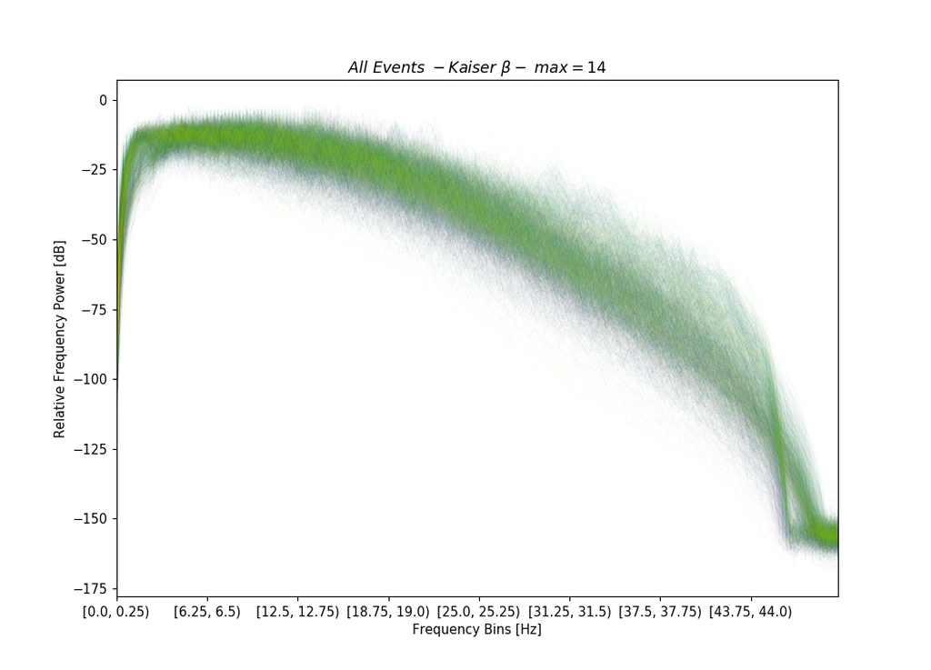

```python
ax = plotter_df.transpose().plot(legend=False, title=r"$All\ Events\ - Kaiser\ \beta -\ max = 14$", lw=0.01, colormap="viridis")
ax.set_xlabel("Frequency Bins [Hz]")
ax.set_ylabel("Relative Frequency Power [dB]")
```

```python
attributes_dataframe.to_csv("../../Data/Attributes/Events/Attributes.csv")
```